# Performance-temperature modeling

PURA acuicultura

4/1/2021

## Background

In Chapter 2 we developed a cumulative growth model that takes an individual fish weight at the beginning of a 24-hour interval and returns the expected weight at the end of the 24-hour interval as input for the following day. At the same time, we also demonstrated how multiplying the estimated daily weight gain by a random error term ‘individualized’ the ‘lifetime’ growth pattern expressed by the model. In this chapter, the same principle will be applied to model fish growth throughout seasonally variable temperature regimes. More specifically, throughout the sinusoidal temperature models developed in Chapter 4.

## Libraries use

The `tidyverse` library was the only library used in this chapter, principally for `dplyr` and `ggplot`.

```r
library(tidyverse)
```

## Introduction

Being ectothermic, fish metabolism is influenced by the temperature of the surrounding water. As a general model, growth increases with increasing temperature until a thermal optimum is achieved. While some individual variation certainly exists, thermal optimum are principally species specific. For example, while the thermal optimum of salmon is around 14$^\circ$C, for tilapia it is nearer to 28$^\circ$C. Above the thermal optimum, growth decreases with increasing temperature.

## Parabolic ‘performance x temperature’ relationships

Based on this general model, one might choose to model ‘performance as a function of temperature’ using something akin to a convex parabola. The following code creates just such a curve for tilapia. The curve employs the vertex form of the parabola equation such that the temperature optimum `T_opt` for tilapia (NB: 28$^\circ$C) can be directly entered into the equation, along with the performance maximum `P_max`, and the coefficient `alpha_1`, which dictates the direction and width of the parabola.

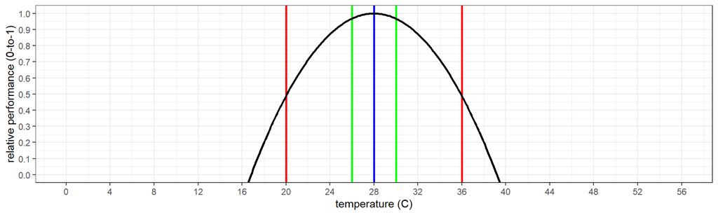

```r
alpha_1 <- -0.008 # dictates the direction and width of the parabola
T_opt <- 28 # temperature optimum of the species
P_max <- 1 # performance maximum

TEMP <- seq(0, 56, by = 0.1) # an array of temperatures between 0 and 2 * T_opt
PERF <- alpha_1 * (TEMP - T_opt)^2 + P_max # sigmoid formula
df_parab <- data.frame(TEMP, PERF) # arrange data frame

df_parab %>%
  ggplot() +
  geom_vline(xintercept = c(20, 36), color = 'red', size = 1) + # add tolerable range
  geom_vline(xintercept = c(26, 30), color = 'green', size = 1) + # add optimum range
  geom_vline(xintercept = T_opt, color = 'blue', size = 1) + # add temperature optimum
  geom_line(aes(x = TEMP, y = PERF), color = 'black', size = 1) +
  scale_x_continuous(breaks = seq(0, 56, by = 4)) +
  scale_y_continuous(breaks = seq(0, 1, by = 0.1)) +
  coord_cartesian(ylim = c(0, 1)) +
  labs(x = "temperature (C)", y = "relative performance (0-to-1)") +
  theme_bw()
```

While the parabola model provides a good general approximation of the relationship between performance and temperature, it is not perfect. For one thing, the relationship is generally not symmetrical. The increase in performance below the temperature optimum is more gradual than the decrease in performance after the temperature optimum. Furthermore, because parabolic relationships extend below 0, the rate of performance change becomes increasingly severe as the thermal limits of the species are approached (NB: 17 and 39$^\circ$C for the example shown). While a parabolic relationship is frequently used for temperatures above the optimum, a sigmoidal relationship might more accurately reflect the relationship with performance for temperatures below the optimum.

## Sigmoidal ‘performance x temperature’ relationships

‘Performance x temperature’ relationships are sometimes depicted as ‘left skewed normal distributions’. Under such depictions the x-axis acts as an asymptote to performance beyond the lower and upper thermal limits. Although formulas for non-normal curves exist it can be less cumbersome to model the relationship through sequential sigmoidal curves. More specifically, a ‘increasing’ sigmoid curve terminating at the temperature optimum is joined to a ‘decreasing’ sigmoid curve commencing at the temperature optimum. The process is demonstrated here.

The next two code blocks employ a general formula for a sigmoid curve with inputs pertaining to the minimum and maximum tolerable temperatures and beta coefficients that are indirectly equated to the inclination of the linear portion of the sigmoid curve. Remember from Chapter 1 that beta coefficients are not directly related to slopes but values less than 1 result in negative slopes while values greater than 1 result in positive slopes. To create the full ‘performance x temperature’ relationship, both ‘increasing’ and ‘decreasing’ sigmoid curves are employed.

### Sigmoid from 0 to the temperature optimum

The following code produces the first half of the ‘performance x temperature’ relationship. The formula takes an x-axis input equivalent to the inflection point of the sigmoid curve (NB: the point at which performance is equal to 0.5). The minimum tolerable temperature `T_min` is employed in the formula. The beta coefficient `beta_1` employs a value of 1.7. Being greater than 1, an ‘increasing’ sigmoid curve is generated. Furthermore, as the beta coefficient increases from 1, the slope of the linear portion becomes increasingly steep. The end result is a sigmoid curve that rises from 0 around 10 to 12$^\circ$C, exhibits ~0.1 performance at 16$^\circ$C, ~0.5 performance at 20$^\circ$C, and approaches 1.0 performance from 26 to 28$^\circ$C.

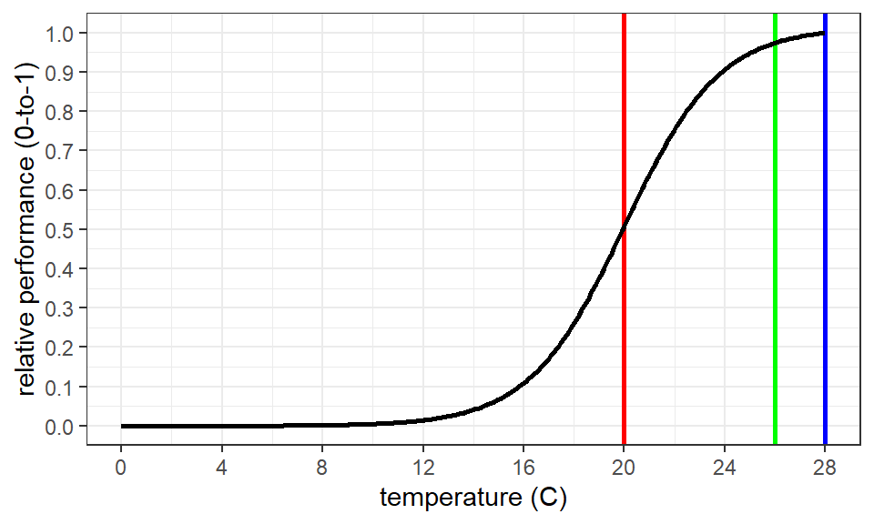

```r
T_min <- 20 # tolerable low temperature of species
beta_1 <- 1.7 # dictates the 'slope' of the sigmoid curve

TEMP <- seq(0, T_opt, by = 0.1)
PERF <- 1 / (1 + beta_1^(-TEMP + T_min))
df_sig_1 <- data.frame(TEMP, PERF)

df_sig_1 %>%
  mutate(PERF = PERF / max(PERF)) %>%
  ggplot() +
  geom_vline(xintercept = T_min, color = 'red', size = 1) + # add tolerable low temp
  geom_vline(xintercept = 26, color = 'green', size = 1) + # add optimum low temp
  geom_vline(xintercept = T_opt, color = 'blue', size = 1) + # add temperature optimum
  geom_line(aes(x = TEMP, y = PERF), size = 1, color = 'black') +
  scale_x_continuous(breaks = seq(0, 28, by = 4)) +
  scale_y_continuous(breaks = seq(0, 1, by = 0.1)) +
  labs(x = "temperature (C)", y = "relative performance (0-to-1)") +
  theme_bw()
```

### Sigmoid from the temperature optimum to infinity

The latter half of the sigmoid curve is created in the same way except the maximum tolerable temperature `T_max` is used in place of `T_min`, and a beta coefficient value of 0.4 is applied to `beta_2`. Being less than 1, an ‘decreasing’ sigmoid curve is generated. For values below 1, as the beta coefficient decreases from 1 towards 0, the slope of the linear portion becomes increasingly steep. The end result is a curve that decreases from 1 between 28 and 30$^\circ$C, exhibits ~0.5 performance at 33$^\circ$C, and approaches 0 between 38 and 40$^\circ$C.

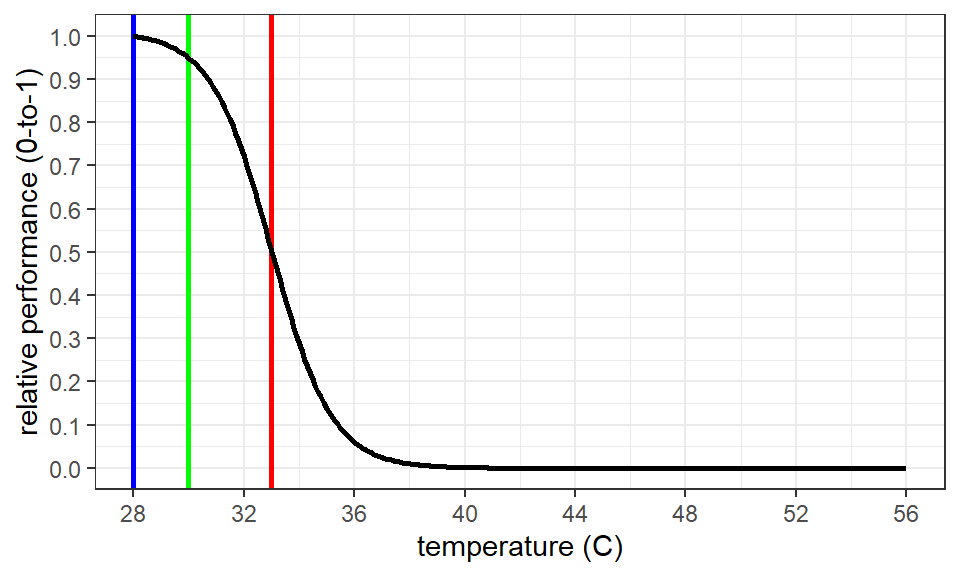

```r
T_max <- 33 # tolerable high temperature of the species
beta_2 <- 0.4 # dictates es the 'slope' of the sigmoid curve

TEMP <- seq(T_opt, 56, by = 0.1)
PERF <- 1 / (1 + beta_2^(-TEMP + T_max))
df_sig_2 <- data.frame(TEMP, PERF)

df_sig_2 %>%
  mutate(PERF = PERF / max(PERF)) %>%
  ggplot() +
  geom_vline(xintercept = T_max, color = 'red', size = 1) + # add tolerable high temp
  geom_vline(xintercept = 30, color = 'green', size = 1) + # add optimum low temp
  geom_vline(xintercept = T_opt, color = 'blue', size = 1) + # add temperature optimum
  geom_line(aes(x = TEMP, y = PERF), size = 1, color = 'black') +
  scale_x_continuous(breaks = seq(28, 56, by = 4)) +
  scale_y_continuous(breaks = seq(0, 1, by = 0.1)) +
  labs(x = "temperature (C)", y = "relative performance (0-to-1)") +
  theme_bw()
```

### Combining sigmoid curves

Rather than simply ‘row binding’ the preceding data frames, the following code was used to assemble the sigmoid curves through the `ifelse()` function. This is an important step in incorporating the function into future models. A temperature array `TEMP` of 56$^\circ$C is first made. Note that 56$^\circ$C was only chosen to make the dimensions of the curve proportional to the sum of the two preceding curves. Using the `ifelse()` function, if `TEMP` is less than or equal to the temperature optimum `T_opt` then the equation for the positively sloped sigmoid curve is employed. If `TEMP` is greater than `T_opt` then the equation for the negatively sloped sigmoid curve is employed. A data frame is then arranged to observed the combined curves.

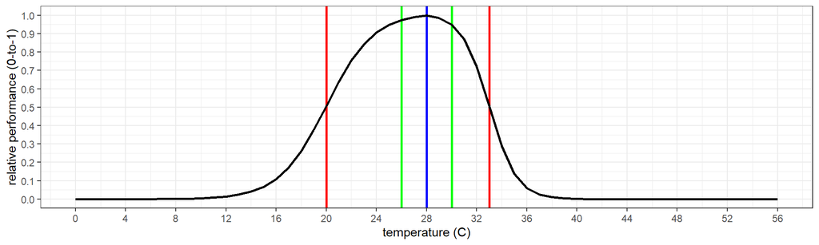

```r
TEMP <- seq(0, 56, by = 1)
PERF <- ifelse(TEMP <= T_opt,
               (1 / (1 + beta_1^(-TEMP + T_min))) / max(df_sig_1$PERF),
               (1 / (1 + beta_2^(-TEMP + T_max))) / max(df_sig_2$PERF))

df_sig <- data.frame(TEMP, PERF)

df_sig %>%
  ggplot() +
  geom_vline(xintercept = c(T_min, T_max), color = 'red', size = 1) + # add tolerable range
  geom_vline(xintercept = c(26, 30), color = 'green', size = 1) + # add optimum range
  geom_vline(xintercept = T_opt, color = 'blue', size = 1) + # add temperature optimum
  geom_line(aes(x = TEMP, y = PERF), size = 1, color = 'black') +
  scale_x_continuous(breaks = seq(0, 56, by = 4)) +
  scale_y_continuous(breaks = seq(0, 1, by = 0.1)) +
  labs(x = "temperature (C)", y = "relative performance (0-to-1)") +
  theme_bw()
```

The two sigmoids combine to produce a curve reminiscent of a ‘left-skewed normal distribution’. The sigmoid curves provide a fairly good estimate of performance based on known thermal limits, tolerances, and optima for the species. In fact, within the tolerable limits of the species (NB: 20 to 33$^\circ$C) the double sigmoid ‘performance x temperature’ relationship is probably as good as any other. The only area of discrepancy lies in the area beyond the upper tolerable temperature (NB: greater than 33$^\circ$C). The underlying biological relationship between temperature and metabolism suggests a more severe, ‘parabolic’ decrease in performance than the asymptotic decay of the sigmoid.

## Combined sigmoid/parabola ‘performance x temperature’ relationships

After exploring both parabolic and sigmoidal ‘performance x temperature’ relationships, it should be clear how a combined sigmoid/parabolic relationship might be developed. The following code develops such a relationship for comparison with the double sigmoid. The first part of the code adjusts the `alpha` coefficient of the previously used parabola equation to reduce its width. From there, it is just a matter of combining the previously used sigmoid curve from 0$^\circ$C to `T_opt` and the adjusted parabola function from `T_opt` to 56$^\circ$C.

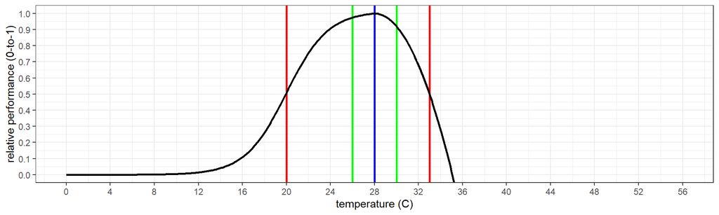

```r
alpha_2 <- -0.02 # dictates the direction and width of the parabola
T_opt <- 28 # temperature optimum of the species
P_max <- 1 # performance maximum

TEMP <- seq(T_opt, 56, by = 0.1) # an array of temperatures between 0 and 2 * T_opt
PERF <- alpha_2 * (TEMP - T_opt)^2 + P_max # sigmoid formula
df_parab_2 <- data.frame(TEMP, PERF) # arrange data frame

TEMP <- seq(0, 56, by = 0.1)
PERF <- ifelse(TEMP <= T_opt,
               (1 / (1 + beta_1^(-TEMP + T_min))) / max(df_sig_1$PERF),
               (alpha_2 * (TEMP - T_opt)^2 + P_max) / max(df_parab_2$PERF))

df_sig_parab <- data.frame(TEMP, PERF)

df_sig_parab %>%
  ggplot() +
  geom_vline(xintercept = c(T_min, T_max), color = 'red', size = 1) + # add tolerable range
  geom_vline(xintercept = c(26, 30), color = 'green', size = 1) + # add optimum range
  geom_vline(xintercept = T_opt, color = 'blue', size = 1) + # add temperature optimum
  geom_line(aes(x = TEMP, y = PERF), size = 1, color = 'black') +
  scale_x_continuous(breaks = seq(0, 56, by = 4)) +
  scale_y_continuous(breaks = seq(0, 1, by = 0.1)) +
  coord_cartesian(ylim = c(0, 1)) +
  labs(x = "temperature (C)", y = "relative performance (0-to-1)") +
  theme_bw()
```

## Hard-coded function for integration into other models

With the ‘performance x temperature’ relationship defined, it is a good idea to create a ‘hard coded’ version for easy incorporation into other models. The following code simply calls the parameters developed in the preceding sections such that they could be directly entered into the formula. The formula is then encompassed within the ‘performance-temperature function’ or `PTF()`. We will use the `PTF()` function in Chapter 5.

```r
T_opt # temperature optimum = 28
beta_1 # beta coefficient = 1.7
T_min # tolerable temperature minimum = 20
max(df_sig_1$PERF) # max performance of sigma curve = 0.9858672
alpha_2 # alpha coefficient = -0.02
P_max # performance maximum = 1
max(df_parab_2$PERF) # max performance of parabola curve = 1

PTF <- function(TEMP) {ifelse(TEMP <= 28,
                       (1 / (1 + 1.7^(-TEMP + 20))) / 0.9858672,
                       (-0.02 * (TEMP - 28)^2 + 1) / 1)}
```

Based on the results from tolerable and optimum temperatures inputs, the `PTF()` function can be verified.

```r
c(PTF(20), PTF(28), PTF(33))
```

```
## [1] 0.5071677 1.0000000 0.5000000
```